# Question

Some basic [2D-transformation matrices](https://en.wikipedia.org/wiki/Transformation_matrix) are shown:

- Horizontal stretch by factor $k$ (with reflection if $k<0$).
  $$\begin{bmatrix}k & 0 \\ 0 &
  1\end{bmatrix}$$
- Vertical stretch by factor $k$ (with reflection if $k<0$).
  $$\begin{bmatrix}1 & 0 \\ 0 &
  k\end{bmatrix}$$
- Rotation by angle $\theta$ radians.
  $$\begin{bmatrix}\cos(\theta) &
  \sin(\theta) \\ -\sin(\theta) &
  \cos(\theta)\end{bmatrix}$$
- Horizontal shearing by factor $k$.
  $$\begin{bmatrix}1 & 0 \\ k &
  1\end{bmatrix}$$
- Vertical shearing by factor $k$.
  $$\begin{bmatrix}1 & k \\ 0 &
  1\end{bmatrix}$$

When multiple transformations are applied, order matters. If $A$ is the first transformation matrix, $B$ is the second, $C$ was the third, and $X$ was a matrix of row vectors, then the result, $X'$, would be found with the following matrix multiplication:
$$X'
= XABC$$
Notice, we defined our transformation matrices as right-operands, so the order matches. If we used (the more standard) left-operand transformation matrices, the order would be reverse with $X$ at the end.

## Problem-specific information

We will use [SageMath](https://sagecell.sagemath.org/) to apply 3 transformations of a unit square. Begin with the points of a unit square.

$$X = \begin{bmatrix}0 & 0 \\ 0 &
1 \\ 1 & 1 \\ 1 & 0\end{bmatrix}$$

```
X = matrix([[0,0],[0,1],[1,1],[1,0]])
polygon(X,xmin=-5,xmax=5,ymin=-5,ymax=5,aspect_ratio=1,color="red")
```

Apply the following transformations in the indicated order:

1. A horizontal shear by factor 0.9.
2. A rotation by angle 1.59.
3. A vertical stretch by factor 1.9.

Which graph is generated when polygon $X$ is plotted in red and polygon $X'$ is plotted in blue?

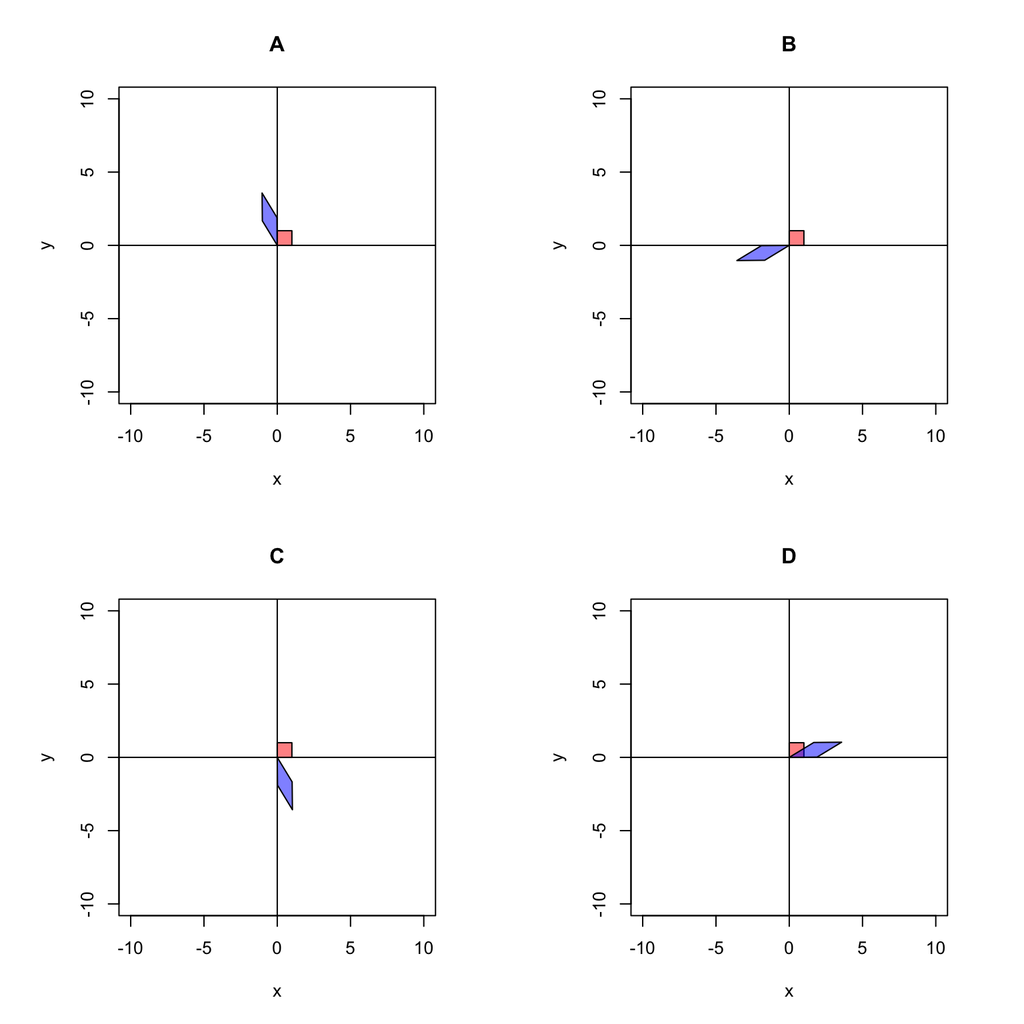

## Answerlist

- A
- B
- C
- D

# Solution

The answer is A.

[SageMath](https://sagecell.sagemath.org/):

```
mygraph = Graphics()
X = matrix([[0,0],[0,1],[1,1],[1,0]])
mygraph += polygon(X,color="red",alpha=0.5)
A = matrix([[1,0],
            [0.9,1]])
B = matrix([[-0.019,1],
            [-1,-0.019]])
C = matrix([[1,0],
            [0,1.9]])
XP = X*A*B*C
mygraph += polygon(XP,color="blue",alpha=0.5)
show(mygraph,xmin=-10,xmax=10,ymin=-10,ymax=10,aspect_ratio=1)
```

# Meta-information

extype: schoice exsolution: 1000 exname: multiple_transforms